# White Matter Development: Analysis

Benjamin Risk

01/15/2023

-correct titles on tract specific bands -Create new version of figure 5, separate from sex effects

```r
library(mgcv)
library(itsadug)
dat_harmonized = read.csv('dat_harmonized.csv',stringsAsFactors = TRUE)
```

### FA

This function extracts the largest age at which there is a significant difference:

```r
# note: full term is 37
maxChronAge = function(GAlow,GAhigh=40,model,ylab,less=TRUE) {
  a=plot_diff(model,view='chor_age',comp=list(GA=c(GAlow,GAhigh)),sim.ci = TRUE, hide.label=TRUE,xlab='Chronological age (days)',ylab=ylab)
  if(less) {
  max(a$chor_age[a$est+a$sim.CI<0])
  } else {
    max(a$chor_age[a$est-a$sim.CI>0])
  }
}
```

The syntax used here is described as the functional anova in the supporting R documentation for ?ti().

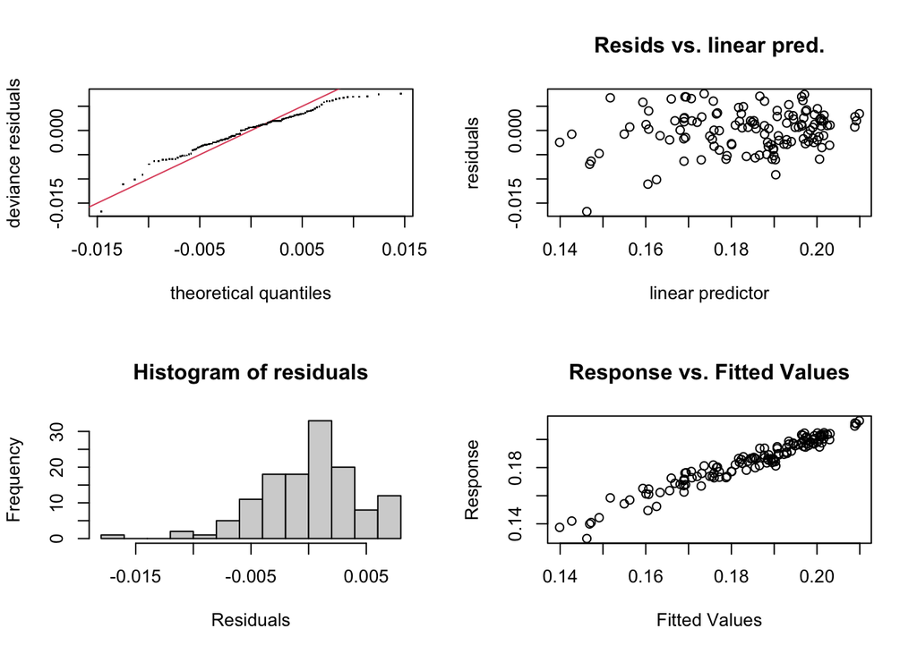

```
##
## Method: REML   Optimizer: outer newton
## full convergence after 9 iterations.
## Gradient range [-0.0001497633,0.0004357979]
## (score -422.5314 & scale 3.015453e-05).
## Hessian positive definite, eigenvalue range [0.001595146,70.92705].
## Model rank =  125 / 125
##
## Basis dimension (k) checking results. Low p-value (k-index<1) may
## indicate that k is too low, especially if edf is close to k'.
##
##                    k'   edf k-index p-value
## ti(chor_age)     8.00  3.50    0.81   0.005 **
## ti(GA)           4.00  1.96    1.11   0.855
## ti(chor_age,GA) 32.00  2.05    1.08   0.840
## s(Unique_ID)    79.00 45.10      NA      NA
## ---
## Signif. codes:  0 '***' 0.001 '**' 0.01 '*' 0.05 '.' 0.1 ' ' 1
```

```r
model0.fa = gam(WB_fa.combat~ti(chor_age,k=9)+ti(GA,k=5)+ti(chor_age,GA,k=c(9,5))+Sex+s(Unique_ID,bs='re'),method='REML',data=dat_harmonized)


# print out the k's:
gam.check(model0.fa)
```

```r
# edf are all far from k', so the default k's suffice.
summary(model0.fa)
```

```
##
## Family: gaussian
## Link function: identity
##
## Formula:
## WB_fa.combat ~ ti(chor_age, k = 9) + ti(GA, k = 5) + ti(chor_age,
##     GA, k = c(9, 5)) + Sex + s(Unique_ID, bs = "re")
##
## Parametric coefficients:
##               Estimate Std. Error t value Pr(>|t|)
## (Intercept)  0.1837594  0.0013419 136.938   <2e-16 ***
## SexM        -0.0006951  0.0017247  -0.403    0.688
## ---
## Signif. codes:  0 '***' 0.001 '**' 0.01 '*' 0.05 '.' 0.1 ' ' 1
##
## Approximate significance of smooth terms:
##                    edf Ref.df       F  p-value
## ti(chor_age)     3.501  4.139 144.438  < 2e-16 ***
## ti(GA)           1.960  2.148  17.675 7.00e-07 ***
## ti(chor_age,GA)  2.049  2.427   5.443  0.00464 **
## s(Unique_ID)    45.102 76.000   1.656 6.18e-06 ***
## ---
## Signif. codes:  0 '***' 0.001 '**' 0.01 '*' 0.05 '.' 0.1 ' ' 1
##
## R-sq.(adj) =  0.896   Deviance explained =   94%
## -REML = -422.53  Scale est. = 3.0155e-05  n = 129
```

```r
  # alternative syntax from gam book, not the same as the syntax used in documentation:
  model0.fa.check = gam(WB_fa.combat~s(chor_age,k=9)+s(GA,k=5)+ti(chor_age,GA,k=c(9,5))+Sex+s(Unique_ID,bs='re'),method='REML',data=dat_harmonized)
  summary(model0.fa.check)
```

```
##
## Family: gaussian
## Link function: identity
##
## Formula:
## WB_fa.combat ~ s(chor_age, k = 9) + s(GA, k = 5) + ti(chor_age,
##     GA, k = c(9, 5)) + Sex + s(Unique_ID, bs = "re")
##
## Parametric coefficients:
##              Estimate Std. Error t value Pr(>|t|)
## (Intercept)  0.183761   0.001341 137.014   <2e-16 ***
## SexM        -0.000697   0.001724  -0.404    0.687
## ---
## Signif. codes:  0 '***' 0.001 '**' 0.01 '*' 0.05 '.' 0.1 ' ' 1
##
## Approximate significance of smooth terms:
##                    edf Ref.df       F  p-value
## s(chor_age)      3.535  4.184 142.886  < 2e-16 ***
## s(GA)            1.950  2.143  16.982 6.89e-07 ***
## ti(chor_age,GA)  2.050  2.432   5.429  0.00469 **
## s(Unique_ID)    45.083 76.000   1.651 6.46e-06 ***
## ---
## Signif. codes:  0 '***' 0.001 '**' 0.01 '*' 0.05 '.' 0.1 ' ' 1
##
## R-sq.(adj) =  0.896   Deviance explained =   94%
## -REML = -419.65  Scale est. = 3.0155e-05  n = 129
```

```r
  # results are not identical, but very similar. Use the ti(x) + ti(z) + ti(x,z) described in ?ti()


  # check it is location invariant:
  dat_harmonized$c_chor_age = scale(dat_harmonized$chor_age,center=TRUE,scale=FALSE)
  dat_harmonized$c_GA = scale(dat_harmonized$GA,center=TRUE,scale=FALSE)

  model0.fa.audit = gam(WB_fa.combat~ti(c_chor_age,k=9)+ti(c_GA,k=5)+ti(c_chor_age,c_GA,k=c(9,5))+Sex+s(Unique_ID,bs='re'),method='REML',data=dat_harmonized)
  summary(model0.fa.audit)
```

```
##
## Family: gaussian
## Link function: identity
##
## Formula:
## WB_fa.combat ~ ti(c_chor_age, k = 9) + ti(c_GA, k = 5) + ti(c_chor_age,
##     c_GA, k = c(9, 5)) + Sex + s(Unique_ID, bs = "re")
##
## Parametric coefficients:
##               Estimate Std. Error t value Pr(>|t|)
## (Intercept)  0.1837594  0.0013419 136.938   <2e-16 ***
## SexM        -0.0006951  0.0017247  -0.403    0.688
## ---
## Signif. codes:  0 '***' 0.001 '**' 0.01 '*' 0.05 '.' 0.1 ' ' 1
##
## Approximate significance of smooth terms:
##                        edf Ref.df       F  p-value
## ti(c_chor_age)       3.501  4.139 144.438  < 2e-16 ***
## ti(c_GA)             1.960  2.148  17.675 7.00e-07 ***
## ti(c_chor_age,c_GA)  2.049  2.427   5.443  0.00464 **
## s(Unique_ID)        45.102 76.000   1.656 6.18e-06 ***
## ---
## Signif. codes:  0 '***' 0.001 '**' 0.01 '*' 0.05 '.' 0.1 ' ' 1
##
## R-sq.(adj) =  0.896   Deviance explained =   94%
## -REML = -422.53  Scale est. = 3.0155e-05  n = 129
```

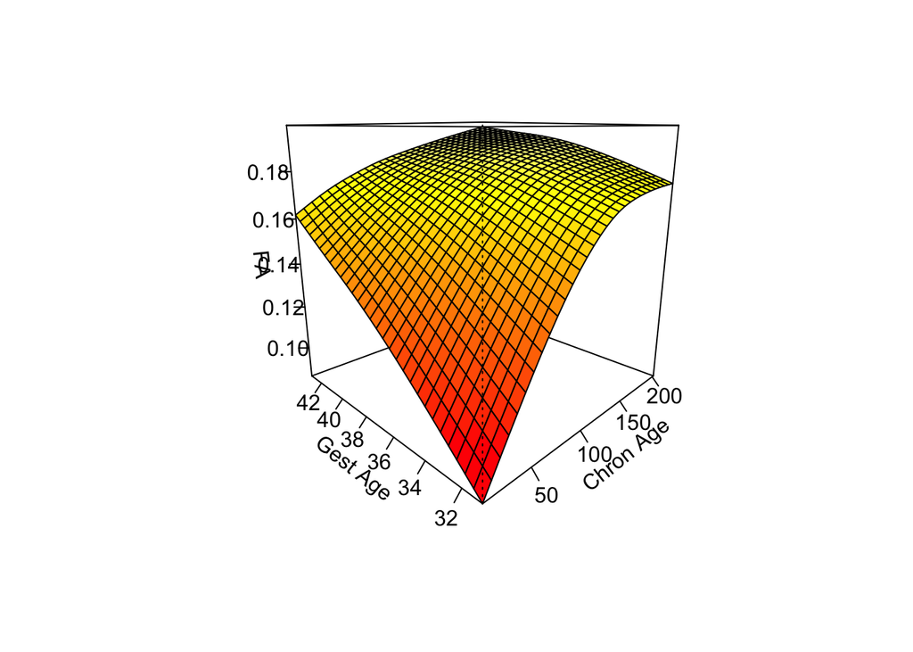

```r
  # good.



vis.gam(model0.fa,view=c('chor_age','GA'),theta=-45,ticktype='detailed',xlab='Chron Age',ylab='Gest Age',zlab='FA')
```

```r
set.seed(123)

tiff('../Figures/DiffCurves_FA.tiff',width=720,height=480,pointsize=20)
par(mfrow=c(2,3))
(ga.35.fa=maxChronAge(GAlow=35,GAhigh=40,model=model0.fa,ylab='Est. difference in FA'))
```

```
## Summary:
##  * Sex : factor; set to the value(s): M.
##  * chor_age : numeric predictor; with 200 values ranging from 10.000000 to 202.000000.
##  * Unique_ID : factor; set to the value(s): 00106_04. (Might be canceled as random effect, check below.)
##  * NOTE : The following random effects columns are canceled: s(Unique_ID)
##
##  * Simultaneous 95%-CI used :
##      Critical value: 2.732
##      Proportion posterior simulations in pointwise CI: 1 (10000 samples)
##      Proportion posterior simulations in simultaneous CI: 1 (10000 samples)
##
```

```
##
## chor_age window(s) of significant difference(s):
##  10.000000 - 102.623116
```

```
## [1] 102.6231
```

```r
(ga.36.fa=maxChronAge(GAlow=36,GAhigh=40,model=model0.fa,ylab='Est. difference in FA'))
```

```
## Summary:
##  * Sex : factor; set to the value(s): M.
##  * chor_age : numeric predictor; with 200 values ranging from 10.000000 to 202.000000.
##  * Unique_ID : factor; set to the value(s): 00106_04. (Might be canceled as random effect, check below.)
##  * NOTE : The following random effects columns are canceled: s(Unique_ID)
##
##  * Simultaneous 95%-CI used :
##      Critical value: 2.704
##      Proportion posterior simulations in pointwise CI: 1 (10000 samples)
##      Proportion posterior simulations in simultaneous CI: 1 (10000 samples)
##
```

```
##
## chor_age window(s) of significant difference(s):
##  10.000000 - 91.045226
```

```
## [1] 91.04523
```

```r
(ga.37.fa=maxChronAge(GAlow=37,GAhigh=40,model=model0.fa,ylab='Est. difference in FA'))
```

```
## Summary:
##  * Sex : factor; set to the value(s): M.
##  * chor_age : numeric predictor; with 200 values ranging from 10.000000 to 202.000000.
##  * Unique_ID : factor; set to the value(s): 00106_04. (Might be canceled as random effect, check below.)
##  * NOTE : The following random effects columns are canceled: s(Unique_ID)
##
##  * Simultaneous 95%-CI used :
##      Critical value: 2.719
##      Proportion posterior simulations in pointwise CI: 1 (10000 samples)
##      Proportion posterior simulations in simultaneous CI: 1 (10000 samples)
##
```

```
##
## chor_age window(s) of significant difference(s):
##  10.000000 - 79.467337
```

```
## [1] 79.46734
```

```r
(ga.38.fa=maxChronAge(GAlow=38,GAhigh=40,model=model0.fa,ylab='Est. difference in FA'))
```

```
## Summary:
##  * Sex : factor; set to the value(s): M.
##  * chor_age : numeric predictor; with 200 values ranging from 10.000000 to 202.000000.
##  * Unique_ID : factor; set to the value(s): 00106_04. (Might be canceled as random effect, check below.)
##  * NOTE : The following random effects columns are canceled: s(Unique_ID)
##
##  * Simultaneous 95%-CI used :
##      Critical value: 2.687
##      Proportion posterior simulations in pointwise CI: 1 (10000 samples)
##      Proportion posterior simulations in simultaneous CI: 1 (10000 samples)
##
```

```
##
## chor_age window(s) of significant difference(s):
##  10.000000 - 68.854271
```

```
## [1] 68.85427
```

```r
(ga.39.fa=maxChronAge(GAlow=39,GAhigh=40,model=model0.fa,ylab='Est. difference in FA'))
```

```
## Summary:
##  * Sex : factor; set to the value(s): M.
##  * chor_age : numeric predictor; with 200 values ranging from 10.000000 to 202.000000.
##  * Unique_ID : factor; set to the value(s): 00106_04. (Might be canceled as random effect, check below.)
##  * NOTE : The following random effects columns are canceled: s(Unique_ID)
##
##  * Simultaneous 95%-CI used :
##      Critical value: 2.63
##      Proportion posterior simulations in pointwise CI: 1 (10000 samples)
##      Proportion posterior simulations in simultaneous CI: 1 (10000 samples)
##
```

```
##
## chor_age window(s) of significant difference(s):
##  10.000000 - 58.241206
```

```
## [1] 58.24121
```

```r
(ga.41.fa=maxChronAge(GAlow=40,GAhigh=41,model=model0.fa,ylab='Est. difference in FA'))
```

```
## Summary:
##  * Sex : factor; set to the value(s): M.
##  * chor_age : numeric predictor; with 200 values ranging from 10.000000 to 202.000000.
##  * Unique_ID : factor; set to the value(s): 00106_04. (Might be canceled as random effect, check below.)
##  * NOTE : The following random effects columns are canceled: s(Unique_ID)
##
##  * Simultaneous 95%-CI used :
##      Critical value: 2.638
##      Proportion posterior simulations in pointwise CI: 1 (10000 samples)
##      Proportion posterior simulations in simultaneous CI: 1 (10000 samples)
##
```

```
##
## chor_age window(s) of significant difference(s):
##  10.000000 - 60.170854
```

```
## [1] 60.17085
```

```r
dev.off()
```

### MD

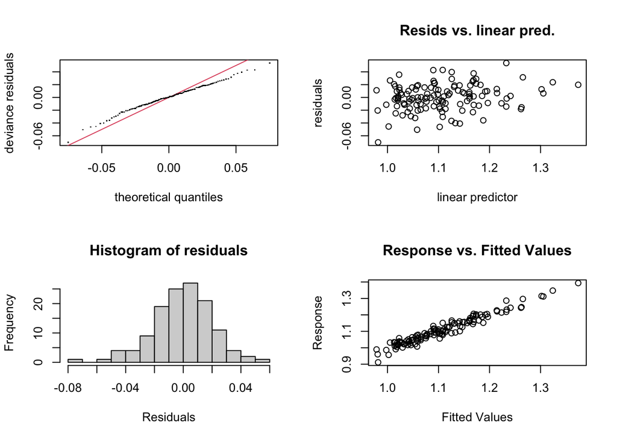

```
##
## Method: REML   Optimizer: outer newton
## full convergence after 8 iterations.
## Gradient range [-5.375222e-05,0.0002039005]
## (score -208.6747 & scale 0.0007959164).
## Hessian positive definite, eigenvalue range [0.0006463986,72.88269].
## Model rank =  125 / 125
##
## Basis dimension (k) checking results. Low p-value (k-index<1) may
## indicate that k is too low, especially if edf is close to k'.
##
##                    k'   edf k-index p-value
## ti(chor_age)     8.00  5.17    0.94    0.23
## ti(GA)           4.00  2.27    1.26    0.99
## ti(chor_age,GA) 32.00  1.65    0.98    0.28
## s(Unique_ID)    79.00 49.89      NA      NA
```

```r
model0.md = gam(WB_md.combat~ti(chor_age,k=9)+ti(GA,k=5)+ti(chor_age,GA,k=c(9,5))+Sex+s(Unique_ID,bs='re'),method='REML',data=dat_harmonized)

gam.check(model0.md) # edf are all far from k'
```

```r
summary(model0.md)
```

```
##
## Family: gaussian
## Link function: identity
##
## Formula:
## WB_md.combat ~ ti(chor_age, k = 9) + ti(GA, k = 5) + ti(chor_age,
##     GA, k = c(9, 5)) + Sex + s(Unique_ID, bs = "re")
##
## Parametric coefficients:
##             Estimate Std. Error t value Pr(>|t|)
## (Intercept) 1.097803   0.007703 142.519   <2e-16 ***
## SexM        0.019444   0.009946   1.955   0.0547 .
## ---
## Signif. codes:  0 '***' 0.001 '**' 0.01 '*' 0.05 '.' 0.1 ' ' 1
##
## Approximate significance of smooth terms:
##                    edf Ref.df      F  p-value
## ti(chor_age)     5.174  5.914 76.172  < 2e-16 ***
## ti(GA)           2.272  2.435 18.827 6.68e-07 ***
## ti(chor_age,GA)  1.646  1.954  2.785   0.0932 .
## s(Unique_ID)    49.887 76.000  2.029 1.73e-06 ***
## ---
## Signif. codes:  0 '***' 0.001 '**' 0.01 '*' 0.05 '.' 0.1 ' ' 1
##
## R-sq.(adj) =   0.89   Deviance explained = 94.1%
## -REML = -208.67  Scale est. = 0.00079592  n = 129
```

```r
tiff('../Figures/DiffCurves_MD.tiff',width=720,height=480,pointsize=20)
par(mfrow=c(2,3))
(ga.35.md=maxChronAge(GAlow=35,GAhigh=40,model=model0.md,less=FALSE,ylab='Est. difference in MD'))
```

```
## Summary:
##  * Sex : factor; set to the value(s): M.
##  * chor_age : numeric predictor; with 200 values ranging from 10.000000 to 202.000000.
##  * Unique_ID : factor; set to the value(s): 00106_04. (Might be canceled as random effect, check below.)
##  * NOTE : The following random effects columns are canceled: s(Unique_ID)
##
##  * Simultaneous 95%-CI used :
##      Critical value: 2.705
##      Proportion posterior simulations in pointwise CI: 1 (10000 samples)
##      Proportion posterior simulations in simultaneous CI: 1 (10000 samples)
##
```

```
##
## chor_age window(s) of significant difference(s):
##  10.000000 - 156.653266
```

```
## [1] 156.6533
```

```r
(ga.36.md=maxChronAge(GAlow=36,GAhigh=40,model=model0.md,less=FALSE,ylab='Est. difference in MD'))
```

```
## Summary:
##  * Sex : factor; set to the value(s): M.
##  * chor_age : numeric predictor; with 200 values ranging from 10.000000 to 202.000000.
##  * Unique_ID : factor; set to the value(s): 00106_04. (Might be canceled as random effect, check below.)
##  * NOTE : The following random effects columns are canceled: s(Unique_ID)
##
##  * Simultaneous 95%-CI used :
##      Critical value: 2.658
##      Proportion posterior simulations in pointwise CI: 1 (10000 samples)
##      Proportion posterior simulations in simultaneous CI: 1 (10000 samples)
##
```

```
##
## chor_age window(s) of significant difference(s):
##  11.929648 - 97.798995
```

```
## [1] 97.79899
```

```r
(ga.37.md=maxChronAge(GAlow=37,GAhigh=40,model=model0.md,less=FALSE,ylab='Est. difference in MD'))
```

```
## Summary:
##  * Sex : factor; set to the value(s): M.
##  * chor_age : numeric predictor; with 200 values ranging from 10.000000 to 202.000000.
##  * Unique_ID : factor; set to the value(s): 00106_04. (Might be canceled as random effect, check below.)
##  * NOTE : The following random effects columns are canceled: s(Unique_ID)
##
##  * Simultaneous 95%-CI used :
##      Critical value: 2.655
##      Proportion posterior simulations in pointwise CI: 1 (10000 samples)
##      Proportion posterior simulations in simultaneous CI: 1 (10000 samples)
##
```

```
##
## chor_age window(s) of significant difference(s):
##  17.718593 - 78.502513
```

```
## [1] 78.50251
```

```r
(ga.38.md=maxChronAge(GAlow=38,GAhigh=40,model=model0.md,less=FALSE,ylab='Est. difference in MD'))
```

```
## Summary:
##  * Sex : factor; set to the value(s): M.
##  * chor_age : numeric predictor; with 200 values ranging from 10.000000 to 202.000000.
##  * Unique_ID : factor; set to the value(s): 00106_04. (Might be canceled as random effect, check below.)
##  * NOTE : The following random effects columns are canceled: s(Unique_ID)
##
##  * Simultaneous 95%-CI used :
##      Critical value: 2.646
##      Proportion posterior simulations in pointwise CI: 1 (10000 samples)
##      Proportion posterior simulations in simultaneous CI: 1 (10000 samples)
##
```

```
##
## chor_age window(s) of significant difference(s):
##  26.402010 - 60.170854
```

```
## [1] 60.17085
```

```r
(ga.39.md=maxChronAge(GAlow=39,GAhigh=40,model=model0.md,less=FALSE,ylab='Est. difference in MD'))
```

```
## Summary:
##  * Sex : factor; set to the value(s): M.
##  * chor_age : numeric predictor; with 200 values ranging from 10.000000 to 202.000000.
##  * Unique_ID : factor; set to the value(s): 00106_04. (Might be canceled as random effect, check below.)
##  * NOTE : The following random effects columns are canceled: s(Unique_ID)
##
##  * Simultaneous 95%-CI used :
##      Critical value: 2.618
##      Proportion posterior simulations in pointwise CI: 1 (10000 samples)
##      Proportion posterior simulations in simultaneous CI: 1 (10000 samples)
##
```

```
##
## Difference is not significant.
```

```
## [1] -Inf
```

```r
(ga.41.md=maxChronAge(GAlow=40,GAhigh=41,model=model0.md,less=FALSE,ylab='Est. difference in MD'))
```

```
## Summary:
##  * Sex : factor; set to the value(s): M.
##  * chor_age : numeric predictor; with 200 values ranging from 10.000000 to 202.000000.
##  * Unique_ID : factor; set to the value(s): 00106_04. (Might be canceled as random effect, check below.)
##  * NOTE : The following random effects columns are canceled: s(Unique_ID)
##
##  * Simultaneous 95%-CI used :
##      Critical value: 2.557
##      Proportion posterior simulations in pointwise CI: 1 (10000 samples)
##      Proportion posterior simulations in simultaneous CI: 1 (10000 samples)
##
```

```
##
## Difference is not significant.
```

```
## [1] -Inf
```

```r
dev.off()
```

```r
#par(mfrow=c(1,2))
#vis.gam(model0.md,view=c('chor_age','GA'),theta=-45,ticktype='detailed',xlab='Chron Age',ylab='Gest Age',zlab='Trace')
```

There is not a significant interaction between chronological age and gestational age for md (p=0.09), and the lines look more parallel than in FA. Nonetheless, there is some evidence of an interaction, as the lines becomes somewhat closer together near 200.

### AD

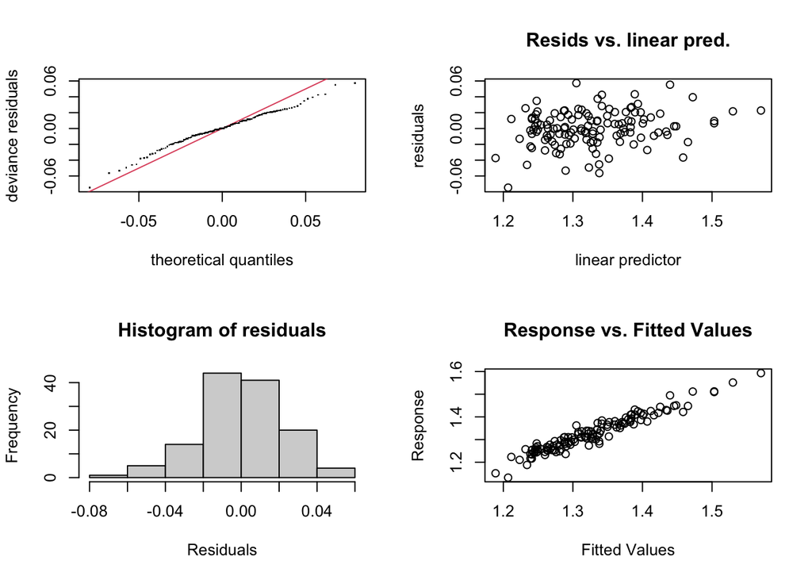

```
##
## Method: REML   Optimizer: outer newton
## full convergence after 8 iterations.
## Gradient range [-0.0001638331,0.0004832802]
## (score -206.2329 & scale 0.0008925716).
## Hessian positive definite, eigenvalue range [0.000130584,71.64775].
## Model rank =  125 / 125
##
## Basis dimension (k) checking results. Low p-value (k-index<1) may
## indicate that k is too low, especially if edf is close to k'.
##
##                    k'   edf k-index p-value
## ti(chor_age)     8.00  5.18    0.94    0.28
## ti(GA)           4.00  2.18    1.27    1.00
## ti(chor_age,GA) 32.00  1.29    0.96    0.30
## s(Unique_ID)    79.00 47.28      NA      NA
```

```r
model0.ad = gam(WB_ad.combat~ti(chor_age,k=9)+ti(GA,k=5)+ti(chor_age,GA,k=c(9,5))+Sex+s(Unique_ID,bs='re'),method='REML',data=dat_harmonized)
gam.check(model0.ad) # edf are all far from k', so the default k's suffice.
```

```r
summary(model0.ad)
```

```
##
## Family: gaussian
## Link function: identity
##
## Formula:
## WB_ad.combat ~ ti(chor_age, k = 9) + ti(GA, k = 5) + ti(chor_age,
##     GA, k = c(9, 5)) + Sex + s(Unique_ID, bs = "re")
##
## Parametric coefficients:
##             Estimate Std. Error t value Pr(>|t|)
## (Intercept) 1.316390   0.007700 170.953   <2e-16 ***
## SexM        0.021698   0.009942   2.183   0.0324 *
## ---
## Signif. codes:  0 '***' 0.001 '**' 0.01 '*' 0.05 '.' 0.1 ' ' 1
##
## Approximate significance of smooth terms:
##                    edf Ref.df      F  p-value
## ti(chor_age)     5.179  5.924 58.708  < 2e-16 ***
## ti(GA)           2.184  2.363 15.867 3.48e-06 ***
## ti(chor_age,GA)  1.288  1.473  2.023    0.209
## s(Unique_ID)    47.280 76.000  1.690 1.26e-05 ***
## ---
## Signif. codes:  0 '***' 0.001 '**' 0.01 '*' 0.05 '.' 0.1 ' ' 1
##
## R-sq.(adj) =   0.86   Deviance explained = 92.2%
## -REML = -206.23  Scale est. = 0.00089257  n = 129
```

```
## Summary:
##  * Sex : factor; set to the value(s): M.
##  * chor_age : numeric predictor; with 200 values ranging from 10.000000 to 202.000000.
##  * Unique_ID : factor; set to the value(s): 00106_04. (Might be canceled as random effect, check below.)
##  * NOTE : The following random effects columns are canceled: s(Unique_ID)
##
##  * Simultaneous 95%-CI used :
##      Critical value: 2.634
##      Proportion posterior simulations in pointwise CI: 1 (10000 samples)
##      Proportion posterior simulations in simultaneous CI: 1 (10000 samples)
##
```

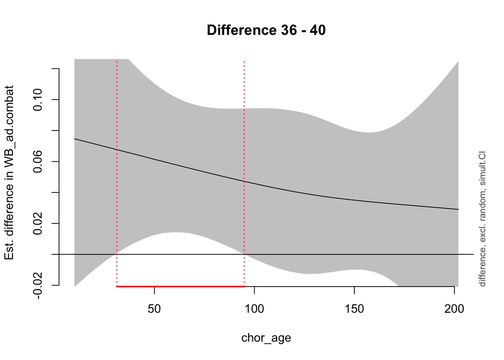

```
##
## chor_age window(s) of significant difference(s):
##  31.226131 - 94.904523
```

```r
plot_diff(model0.ad,view='chor_age',comp=list(GA=c(36,40)),sim.ci = TRUE)
```

```r
tiff('../Figures/DiffCurves_AD.tiff',width=720,height=480,pointsize=20)
par(mfrow=c(2,3))
(ga.35.ad=maxChronAge(GAlow=35,GAhigh=40,model=model0.ad,less=FALSE,ylab='Est. difference in AD'))
```

```
## Summary:
##  * Sex : factor; set to the value(s): M.
##  * chor_age : numeric predictor; with 200 values ranging from 10.000000 to 202.000000.
##  * Unique_ID : factor; set to the value(s): 00106_04. (Might be canceled as random effect, check below.)
##  * NOTE : The following random effects columns are canceled: s(Unique_ID)
##
##  * Simultaneous 95%-CI used :
##      Critical value: 2.653
##      Proportion posterior simulations in pointwise CI: 1 (10000 samples)
##      Proportion posterior simulations in simultaneous CI: 1 (10000 samples)
##
```

```
##
## chor_age window(s) of significant difference(s):
##  24.472362 - 119.989950
##  139.286432 - 153.758794
```

```
## [1] 153.7588
```

```r
(ga.36.ad=maxChronAge(GAlow=36,GAhigh=40,model=model0.ad,less=FALSE,ylab='Est. difference in AD'))
```

```
## Summary:
##  * Sex : factor; set to the value(s): M.
##  * chor_age : numeric predictor; with 200 values ranging from 10.000000 to 202.000000.
##  * Unique_ID : factor; set to the value(s): 00106_04. (Might be canceled as random effect, check below.)
##  * NOTE : The following random effects columns are canceled: s(Unique_ID)
##
##  * Simultaneous 95%-CI used :
##      Critical value: 2.623
##      Proportion posterior simulations in pointwise CI: 1 (10000 samples)
##      Proportion posterior simulations in simultaneous CI: 1 (10000 samples)
##
```

```
##
## chor_age window(s) of significant difference(s):
##  30.261307 - 94.904523
```

```
## [1] 94.90452
```

```r
(ga.37.ad=maxChronAge(GAlow=37,GAhigh=40,model=model0.ad,less=FALSE,ylab='Est. difference in AD'))
```

```
## Summary:
##  * Sex : factor; set to the value(s): M.
##  * chor_age : numeric predictor; with 200 values ranging from 10.000000 to 202.000000.
##  * Unique_ID : factor; set to the value(s): 00106_04. (Might be canceled as random effect, check below.)
##  * NOTE : The following random effects columns are canceled: s(Unique_ID)
##
##  * Simultaneous 95%-CI used :
##      Critical value: 2.616
##      Proportion posterior simulations in pointwise CI: 1 (10000 samples)
##      Proportion posterior simulations in simultaneous CI: 1 (10000 samples)
##
```

```
##
## chor_age window(s) of significant difference(s):
##  39.909548 - 75.608040
```

```
## [1] 75.60804
```

```r
(ga.38.ad=maxChronAge(GAlow=38,GAhigh=40,model=model0.ad,less=FALSE,ylab='Est. difference in AD'))
```

```
## Summary:
##  * Sex : factor; set to the value(s): M.
##  * chor_age : numeric predictor; with 200 values ranging from 10.000000 to 202.000000.
##  * Unique_ID : factor; set to the value(s): 00106_04. (Might be canceled as random effect, check below.)
##  * NOTE : The following random effects columns are canceled: s(Unique_ID)
##
##  * Simultaneous 95%-CI used :
##      Critical value: 2.586
##      Proportion posterior simulations in pointwise CI: 1 (10000 samples)
##      Proportion posterior simulations in simultaneous CI: 1 (10000 samples)
##
```

```
##
## Difference is not significant.
```

```
## [1] -Inf
```

```r
(ga.39.ad=maxChronAge(GAlow=39,GAhigh=40,model=model0.ad,less=FALSE,ylab='Est. difference in AD'))
```

```
## Summary:
##  * Sex : factor; set to the value(s): M.
##  * chor_age : numeric predictor; with 200 values ranging from 10.000000 to 202.000000.
##  * Unique_ID : factor; set to the value(s): 00106_04. (Might be canceled as random effect, check below.)
##  * NOTE : The following random effects columns are canceled: s(Unique_ID)
##
##  * Simultaneous 95%-CI used :
##      Critical value: 2.557
##      Proportion posterior simulations in pointwise CI: 1 (10000 samples)
##      Proportion posterior simulations in simultaneous CI: 1 (10000 samples)
##
```

```
##
## Difference is not significant.
```

```
## [1] -Inf
```

```r
(ga.41.ad=maxChronAge(GAlow=40,GAhigh=41,model=model0.ad,less=FALSE,ylab='Est. difference in AD'))
```

```
## Summary:
##  * Sex : factor; set to the value(s): M.
##  * chor_age : numeric predictor; with 200 values ranging from 10.000000 to 202.000000.
##  * Unique_ID : factor; set to the value(s): 00106_04. (Might be canceled as random effect, check below.)
##  * NOTE : The following random effects columns are canceled: s(Unique_ID)
##
##  * Simultaneous 95%-CI used :
##      Critical value: 2.526
##      Proportion posterior simulations in pointwise CI: 1 (10000 samples)
##      Proportion posterior simulations in simultaneous CI: 1 (10000 samples)
##
```

```
##
## Difference is not significant.
```

```
## [1] -Inf
```

```r
dev.off()
```

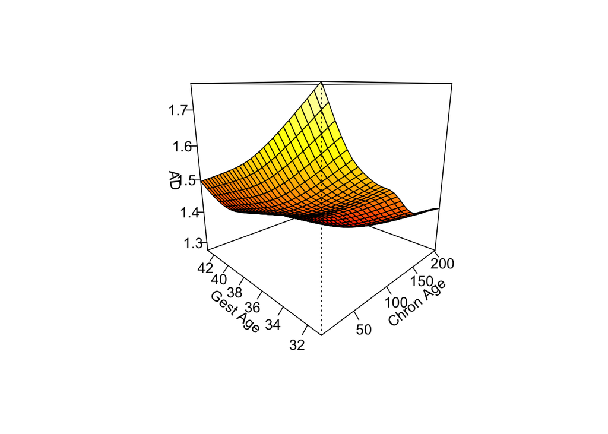

```r
vis.gam(model0.ad,view=c('chor_age','GA'),theta=-45,ticktype='detailed',xlab='Chron Age',ylab='Gest Age',zlab='AD')
```

### RD

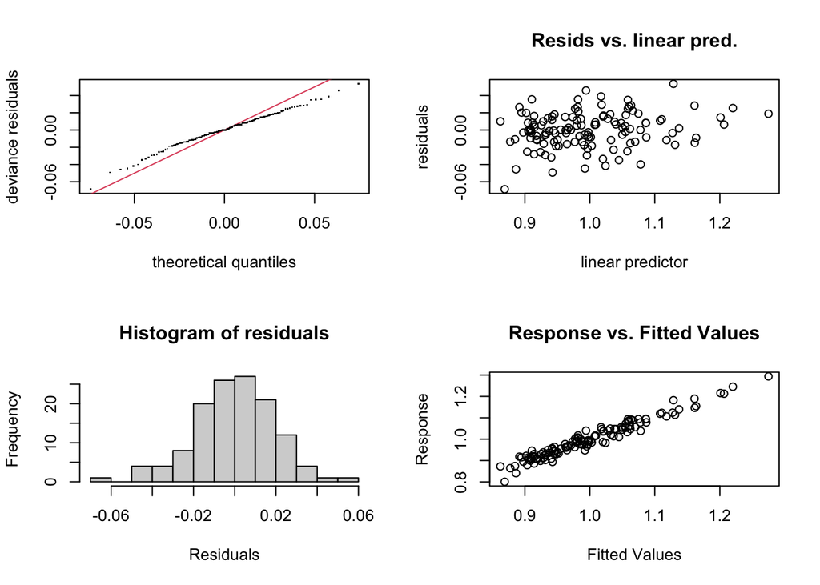

```
##
## Method: REML   Optimizer: outer newton
## full convergence after 6 iterations.
## Gradient range [-8.665913e-05,0.0003241593]
## (score -208.4639 & scale 0.0007796762).
## Hessian positive definite, eigenvalue range [0.00207769,73.31331].
## Model rank =  125 / 125
##
## Basis dimension (k) checking results. Low p-value (k-index<1) may
## indicate that k is too low, especially if edf is close to k'.
##
##                    k'   edf k-index p-value
## ti(chor_age)     8.00  5.11    0.94    0.21
## ti(GA)           4.00  2.30    1.26    1.00
## ti(chor_age,GA) 32.00  1.78    0.97    0.32
## s(Unique_ID)    79.00 50.74      NA      NA
```

```r
model0.rd = gam(WB_rd.combat~ti(chor_age,k=9)+ti(GA,k=5)+ti(chor_age,GA,k=c(9,5))+Sex+s(Unique_ID,bs='re'),method='REML',data=dat_harmonized)
gam.check(model0.rd) # edf are all far from k', so the default k's suffice.
```

```r
summary(model0.rd)
```

```
##
## Family: gaussian
## Link function: identity
##
## Formula:
## WB_rd.combat ~ ti(chor_age, k = 9) + ti(GA, k = 5) + ti(chor_age,
##     GA, k = c(9, 5)) + Sex + s(Unique_ID, bs = "re")
##
## Parametric coefficients:
##             Estimate Std. Error t value Pr(>|t|)
## (Intercept) 0.988452   0.007775  127.13   <2e-16 ***
## SexM        0.018368   0.010038    1.83   0.0717 .
## ---
## Signif. codes:  0 '***' 0.001 '**' 0.01 '*' 0.05 '.' 0.1 ' ' 1
##
## Approximate significance of smooth terms:
##                    edf Ref.df      F  p-value
## ti(chor_age)     5.108  5.848 84.665  < 2e-16 ***
## ti(GA)           2.297  2.455 16.394 4.16e-07 ***
## ti(chor_age,GA)  1.776  2.117  2.947   0.0561 .
## s(Unique_ID)    50.737 76.000  2.167 8.52e-07 ***
## ---
## Signif. codes:  0 '***' 0.001 '**' 0.01 '*' 0.05 '.' 0.1 ' ' 1
##
## R-sq.(adj) =  0.899   Deviance explained = 94.7%
## -REML = -208.46  Scale est. = 0.00077968  n = 129
```

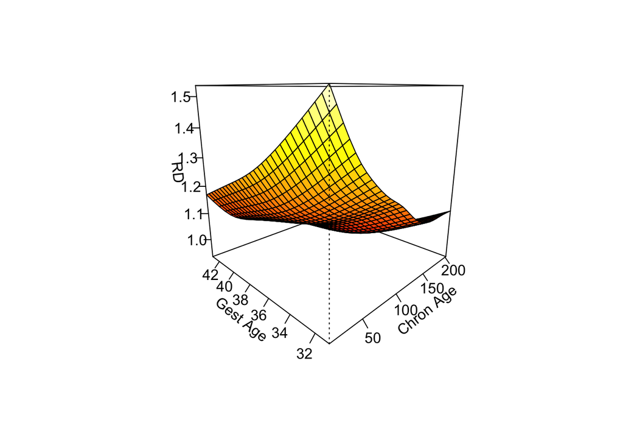

```r
vis.gam(model0.rd,view=c('chor_age','GA'),theta=-45,ticktype='detailed',xlab='Chron Age',ylab='Gest Age',zlab='RD')
```

```r
tiff('../Figures/DiffCurves_RD.tiff',width=720,height=480,pointsize=20)
par(mfrow=c(2,3))
(ga.35.rd=maxChronAge(GAlow=35,GAhigh=40,model=model0.rd,less=FALSE,ylab='Est. difference in RD'))
```

```
## Summary:
##  * Sex : factor; set to the value(s): M.
##  * chor_age : numeric predictor; with 200 values ranging from 10.000000 to 202.000000.
##  * Unique_ID : factor; set to the value(s): 00106_04. (Might be canceled as random effect, check below.)
##  * NOTE : The following random effects columns are canceled: s(Unique_ID)
##
##  * Simultaneous 95%-CI used :
##      Critical value: 2.683
##      Proportion posterior simulations in pointwise CI: 1 (10000 samples)
##      Proportion posterior simulations in simultaneous CI: 1 (10000 samples)
##
```

```
##
## chor_age window(s) of significant difference(s):
##  10.000000 - 158.582915
```

```
## [1] 158.5829
```

```r
(ga.36.rd=maxChronAge(GAlow=36,GAhigh=40,model=model0.rd,less=FALSE,ylab='Est. difference in RD'))
```

```
## Summary:
##  * Sex : factor; set to the value(s): M.
##  * chor_age : numeric predictor; with 200 values ranging from 10.000000 to 202.000000.
##  * Unique_ID : factor; set to the value(s): 00106_04. (Might be canceled as random effect, check below.)
##  * NOTE : The following random effects columns are canceled: s(Unique_ID)
##
##  * Simultaneous 95%-CI used :
##      Critical value: 2.658
##      Proportion posterior simulations in pointwise CI: 1 (10000 samples)
##      Proportion posterior simulations in simultaneous CI: 1 (10000 samples)
##
```

```
##
## chor_age window(s) of significant difference(s):
##  10.000000 - 98.763819
```

```
## [1] 98.76382
```

```r
(ga.37.rd=maxChronAge(GAlow=37,GAhigh=40,model=model0.rd,less=FALSE,ylab='Est. difference in RD'))
```

```
## Summary:
##  * Sex : factor; set to the value(s): M.
##  * chor_age : numeric predictor; with 200 values ranging from 10.000000 to 202.000000.
##  * Unique_ID : factor; set to the value(s): 00106_04. (Might be canceled as random effect, check below.)
##  * NOTE : The following random effects columns are canceled: s(Unique_ID)
##
##  * Simultaneous 95%-CI used :
##      Critical value: 2.676
##      Proportion posterior simulations in pointwise CI: 1 (10000 samples)
##      Proportion posterior simulations in simultaneous CI: 1 (10000 samples)
##
```

```
##
## chor_age window(s) of significant difference(s):
##  12.894472 - 79.467337
```

```
## [1] 79.46734
```

```r
(ga.38.rd=maxChronAge(GAlow=38,GAhigh=40,model=model0.rd,less=FALSE,ylab='Est. difference in RD'))
```

```
## Summary:
##  * Sex : factor; set to the value(s): M.
##  * chor_age : numeric predictor; with 200 values ranging from 10.000000 to 202.000000.
##  * Unique_ID : factor; set to the value(s): 00106_04. (Might be canceled as random effect, check below.)
##  * NOTE : The following random effects columns are canceled: s(Unique_ID)
##
##  * Simultaneous 95%-CI used :
##      Critical value: 2.67
##      Proportion posterior simulations in pointwise CI: 1 (10000 samples)
##      Proportion posterior simulations in simultaneous CI: 1 (10000 samples)
##
```

```
##
## chor_age window(s) of significant difference(s):
##  18.683417 - 61.135678
```

```
## [1] 61.13568
```

```r
(ga.39.rd=maxChronAge(GAlow=39,GAhigh=40,model=model0.rd,less=FALSE,ylab='Est. difference in RD'))
```

```
## Summary:
##  * Sex : factor; set to the value(s): M.
##  * chor_age : numeric predictor; with 200 values ranging from 10.000000 to 202.000000.
##  * Unique_ID : factor; set to the value(s): 00106_04. (Might be canceled as random effect, check below.)
##  * NOTE : The following random effects columns are canceled: s(Unique_ID)
##
##  * Simultaneous 95%-CI used :
##      Critical value: 2.62
##      Proportion posterior simulations in pointwise CI: 1 (10000 samples)
##      Proportion posterior simulations in simultaneous CI: 1 (10000 samples)
##
```

```
##
## Difference is not significant.
```

```
## [1] -Inf
```

```r
(ga.41.rd=maxChronAge(GAlow=40,GAhigh=41,model=model0.rd,less=FALSE,ylab='Est. difference in RD'))
```

```
## Summary:
##  * Sex : factor; set to the value(s): M.
##  * chor_age : numeric predictor; with 200 values ranging from 10.000000 to 202.000000.
##  * Unique_ID : factor; set to the value(s): 00106_04. (Might be canceled as random effect, check below.)
##  * NOTE : The following random effects columns are canceled: s(Unique_ID)
##
##  * Simultaneous 95%-CI used :
##      Critical value: 2.537
##      Proportion posterior simulations in pointwise CI: 1 (10000 samples)
##      Proportion posterior simulations in simultaneous CI: 1 (10000 samples)
##
```

```
##
## Difference is not significant.
```

```
## [1] -Inf
```

```r
dev.off()
```

There is a trend interaction between chronological and gestation age on RD, but overall the lines are parallel.

### Plots of gestational age at chronological age = 30:

```r
tiff('../Figures/GestationalAge_30_90_180.tiff',width=1080,height=640,pointsize=18)
par(mfrow=c(2,4))

focal_chron=30
plot_smooth(model0.fa, view="GA",cond=list(chor_age=focal_chron),lwd=2,sim.ci=TRUE,ylab='Whole-brain FA',xlab='Gestational age at birth (weeks)'
, hide.label=TRUE,main='A',xlim=c(35,41),ylim=c(0.125,0.21),rug=FALSE,col='slateblue1')
```

```
## Summary:
##  * Sex : factor; set to the value(s): M.
##  * chor_age : numeric predictor; set to the value(s): 30.
##  * GA : numeric predictor; with 200 values ranging from 35.000000 to 41.000000.
##  * Unique_ID : factor; set to the value(s): 00106_04. (Might be canceled as random effect, check below.)
##  * NOTE : The following random effects columns are canceled: s(Unique_ID)
##
##  * Simultaneous 95%-CI used :
##      Critical value: 2.493
##      Proportion posterior simulations in pointwise CI: 0.76 (10000 samples)
##      Proportion posterior simulations in simultaneous CI: 0.95 (10000 samples)
##
```

```r
focal_chron=90
plot_smooth(model0.fa, view="GA",cond=list(chor_age=focal_chron),lwd=2,sim.ci=TRUE,ylab='Whole-brain FA ',xlab='Gestational age at birth (weeks)'
, hide.label=TRUE,main='A',xlim=c(35,41),rug=FALSE,col='slateblue3',add=TRUE)
```

```
## Summary:
##  * Sex : factor; set to the value(s): M.
##  * chor_age : numeric predictor; set to the value(s): 90.
##  * GA : numeric predictor; with 200 values ranging from 35.000000 to 41.000000.
##  * Unique_ID : factor; set to the value(s): 00106_04. (Might be canceled as random effect, check below.)
##  * NOTE : The following random effects columns are canceled: s(Unique_ID)
##
##  * Simultaneous 95%-CI used :
##      Critical value: 2.519
##      Proportion posterior simulations in pointwise CI: 0.72 (10000 samples)
##      Proportion posterior simulations in simultaneous CI: 0.95 (10000 samples)
##
```

```r
focal_chron=180
plot_smooth(model0.fa, view="GA",cond=list(chor_age=focal_chron),lwd=2,sim.ci=TRUE,ylab='Whole-brain FA ',xlab='Gestational age at birth (weeks)'
, hide.label=TRUE,main='A',xlim=c(35,41),rug=FALSE,col='darkslateblue',add=TRUE)
```

```
## Summary:
##  * Sex : factor; set to the value(s): M.
##  * chor_age : numeric predictor; set to the value(s): 180.
##  * GA : numeric predictor; with 200 values ranging from 35.000000 to 41.000000.
##  * Unique_ID : factor; set to the value(s): 00106_04. (Might be canceled as random effect, check below.)
##  * NOTE : The following random effects columns are canceled: s(Unique_ID)
##
##  * Simultaneous 95%-CI used :
##      Critical value: 2.488
##      Proportion posterior simulations in pointwise CI: 0.77 (10000 samples)
##      Proportion posterior simulations in simultaneous CI: 0.95 (10000 samples)
##
```

```r
legend(x='bottomright',legend=c('30 days','90 days','180 days'),lty=1,lwd=2,col=c('slateblue1','slateblue3','darkslateblue'),bty='n')

focal_chron=30
plot_smooth(model0.md, view="GA",cond=list(chor_age=focal_chron),lwd=2,sim.ci=TRUE,ylab='Whole-brain MD',xlab='Gestational age at birth (weeks)',hide.label=TRUE,main='B',xlim=c(35,41),rug=FALSE,col='slateblue1',ylim=c(0.95,1.4))
```

```
## Summary:
##  * Sex : factor; set to the value(s): M.
##  * chor_age : numeric predictor; set to the value(s): 30.
##  * GA : numeric predictor; with 200 values ranging from 35.000000 to 41.000000.
##  * Unique_ID : factor; set to the value(s): 00106_04. (Might be canceled as random effect, check below.)
##  * NOTE : The following random effects columns are canceled: s(Unique_ID)
##
##  * Simultaneous 95%-CI used :
##      Critical value: 2.499
##      Proportion posterior simulations in pointwise CI: 0.76 (10000 samples)
##      Proportion posterior simulations in simultaneous CI: 0.96 (10000 samples)
##
```

```r
focal_chron=90
plot_smooth(model0.md, view="GA",cond=list(chor_age=focal_chron),lwd=2,sim.ci=TRUE,ylab='Whole-brain MD ',xlab='Gestational age at birth (weeks)',hide.label=TRUE,main='B',xlim=c(35,41),rug=FALSE,col='slateblue3',ylim=c(0.95,1.4),add=TRUE)
```

```
## Summary:
##  * Sex : factor; set to the value(s): M.
##  * chor_age : numeric predictor; set to the value(s): 90.
##  * GA : numeric predictor; with 200 values ranging from 35.000000 to 41.000000.
##  * Unique_ID : factor; set to the value(s): 00106_04. (Might be canceled as random effect, check below.)
##  * NOTE : The following random effects columns are canceled: s(Unique_ID)
##
##  * Simultaneous 95%-CI used :
##      Critical value: 2.515
##      Proportion posterior simulations in pointwise CI: 0.75 (10000 samples)
##      Proportion posterior simulations in simultaneous CI: 0.95 (10000 samples)
##
```

```r
focal_chron=180
plot_smooth(model0.md, view="GA",cond=list(chor_age=focal_chron),lwd=2,sim.ci=TRUE,ylab='Whole-brain MD',xlab='Gestational age at birth (weeks)',hide.label=TRUE,main='B',xlim=c(35,41),rug=FALSE,col='darkslateblue',ylim=c(0.95,1.4),add=TRUE)
```

```
## Summary:
##  * Sex : factor; set to the value(s): M.
##  * chor_age : numeric predictor; set to the value(s): 180.
##  * GA : numeric predictor; with 200 values ranging from 35.000000 to 41.000000.
##  * Unique_ID : factor; set to the value(s): 00106_04. (Might be canceled as random effect, check below.)
##  * NOTE : The following random effects columns are canceled: s(Unique_ID)
##
##  * Simultaneous 95%-CI used :
##      Critical value: 2.478
##      Proportion posterior simulations in pointwise CI: 0.75 (10000 samples)
##      Proportion posterior simulations in simultaneous CI: 0.94 (10000 samples)
##
```

```r
focal_chron=30
plot_smooth(model0.ad, view="GA",cond=list(chor_age=focal_chron),lwd=2,sim.ci=TRUE,ylab='Whole-brain AD',xlab='Gestational age at birth (weeks)',hide.label=TRUE,main='C',xlim=c(35,41),rug=FALSE,col='slateblue1',ylim=c(1.2,1.6))
```

```
## Summary:
##  * Sex : factor; set to the value(s): M.
##  * chor_age : numeric predictor; set to the value(s): 30.
##  * GA : numeric predictor; with 200 values ranging from 35.000000 to 41.000000.
##  * Unique_ID : factor; set to the value(s): 00106_04. (Might be canceled as random effect, check below.)
##  * NOTE : The following random effects columns are canceled: s(Unique_ID)
##
##  * Simultaneous 95%-CI used :
##      Critical value: 2.453
##      Proportion posterior simulations in pointwise CI: 0.7 (10000 samples)
##      Proportion posterior simulations in simultaneous CI: 0.95 (10000 samples)
##
```

```r
focal_chron=90
plot_smooth(model0.ad, view="GA",cond=list(chor_age=focal_chron),lwd=2,sim.ci=TRUE,ylab='Whole-brain AD  age',xlab='Gestational age at birth (weeks)',hide.label=TRUE,main='C',xlim=c(35,41),rug=FALSE,col='slateblue3',add=TRUE)
```

```
## Summary:
##  * Sex : factor; set to the value(s): M.
##  * chor_age : numeric predictor; set to the value(s): 90.
##  * GA : numeric predictor; with 200 values ranging from 35.000000 to 41.000000.
##  * Unique_ID : factor; set to the value(s): 00106_04. (Might be canceled as random effect, check below.)
##  * NOTE : The following random effects columns are canceled: s(Unique_ID)
##
##  * Simultaneous 95%-CI used :
##      Critical value: 2.517
##      Proportion posterior simulations in pointwise CI: 0.74 (10000 samples)
##      Proportion posterior simulations in simultaneous CI: 0.95 (10000 samples)
##
```

```r
focal_chron=180
plot_smooth(model0.ad, view="GA",cond=list(chor_age=focal_chron),lwd=2,sim.ci=TRUE,ylab='Whole-brain AD',xlab='Gestational age at birth (weeks)',hide.label=TRUE,main='C',xlim=c(35,41),rug=FALSE,col='darkslateblue',add=TRUE)
```

```
## Summary:
##  * Sex : factor; set to the value(s): M.
##  * chor_age : numeric predictor; set to the value(s): 180.
##  * GA : numeric predictor; with 200 values ranging from 35.000000 to 41.000000.
##  * Unique_ID : factor; set to the value(s): 00106_04. (Might be canceled as random effect, check below.)
##  * NOTE : The following random effects columns are canceled: s(Unique_ID)
##
##  * Simultaneous 95%-CI used :
##      Critical value: 2.488
##      Proportion posterior simulations in pointwise CI: 0.71 (10000 samples)
##      Proportion posterior simulations in simultaneous CI: 0.95 (10000 samples)
##
```

```r
focal_chron=30
plot_smooth(model0.rd, view="GA",cond=list(chor_age=focal_chron),lwd=2,sim.ci=TRUE,ylab='Whole-brain RD',xlab='Gestational age at birth (weeks)',hide.label=TRUE,main='D',xlim=c(35,41),rug=FALSE,col='slateblue1',ylim=c(0.85,1.3))
```

```
## Summary:
##  * Sex : factor; set to the value(s): M.
##  * chor_age : numeric predictor; set to the value(s): 30.
##  * GA : numeric predictor; with 200 values ranging from 35.000000 to 41.000000.
##  * Unique_ID : factor; set to the value(s): 00106_04. (Might be canceled as random effect, check below.)
##  * NOTE : The following random effects columns are canceled: s(Unique_ID)
##
##  * Simultaneous 95%-CI used :
##      Critical value: 2.5
##      Proportion posterior simulations in pointwise CI: 0.76 (10000 samples)
##      Proportion posterior simulations in simultaneous CI: 0.96 (10000 samples)
##
```

```r
focal_chron=90
plot_smooth(model0.rd, view="GA",cond=list(chor_age=focal_chron),lwd=2,sim.ci=TRUE,ylab='Whole-brain RD',xlab='Gestational age at birth (weeks)',hide.label=TRUE,main='D',xlim=c(35,41),rug=FALSE,col='slateblue3',add=TRUE)
```

```
## Summary:
##  * Sex : factor; set to the value(s): M.
##  * chor_age : numeric predictor; set to the value(s): 90.
##  * GA : numeric predictor; with 200 values ranging from 35.000000 to 41.000000.
##  * Unique_ID : factor; set to the value(s): 00106_04. (Might be canceled as random effect, check below.)
##  * NOTE : The following random effects columns are canceled: s(Unique_ID)
##
##  * Simultaneous 95%-CI used :
##      Critical value: 2.49
##      Proportion posterior simulations in pointwise CI: 0.75 (10000 samples)
##      Proportion posterior simulations in simultaneous CI: 0.95 (10000 samples)
##
```

```r
focal_chron=180
plot_smooth(model0.rd, view="GA",cond=list(chor_age=focal_chron),lwd=2,sim.ci=TRUE,ylab='Whole-brain RD',xlab='Gestational age at birth (weeks)',hide.label=TRUE,main='D',xlim=c(35,41),rug=FALSE,col='darkslateblue',add=TRUE)
```

```
## Summary:
##  * Sex : factor; set to the value(s): M.
##  * chor_age : numeric predictor; set to the value(s): 180.
##  * GA : numeric predictor; with 200 values ranging from 35.000000 to 41.000000.
##  * Unique_ID : factor; set to the value(s): 00106_04. (Might be canceled as random effect, check below.)
##  * NOTE : The following random effects columns are canceled: s(Unique_ID)
##
##  * Simultaneous 95%-CI used :
##      Critical value: 2.497
##      Proportion posterior simulations in pointwise CI: 0.76 (10000 samples)
##      Proportion posterior simulations in simultaneous CI: 0.95 (10000 samples)
##
```

```r
### Plots of growth curves for the four dti measures at different GA:

#tiff('../Figures/GestandChronAgeFAMDADRD.tiff',width=1080,height=320,pointsize=18)
#par(mfrow=c(1,4))

######### FA:
cColors = viridis::plasma(15)
plot_smooth(model0.fa, view="chor_age",cond=list(GA=35),col=cColors[1],rug=FALSE,ylim=c(0.12,0.205),lwd=2,se=0,ylab='Whole-brain FA',xlab='Chronological age (days)',hide.label=TRUE,main='E',xlim=c(10,202))
```

```
## Summary:
##  * Sex : factor; set to the value(s): M.
##  * chor_age : numeric predictor; with 30 values ranging from 10.000000 to 202.000000.
##  * GA : numeric predictor; set to the value(s): 35.
##  * Unique_ID : factor; set to the value(s): 00106_04. (Might be canceled as random effect, check below.)
##  * NOTE : The following random effects columns are canceled: s(Unique_ID)
##
```

```r
plot_smooth(model0.fa, view="chor_age",cond=list(GA=36),col=cColors[3],add=TRUE,rug=FALSE,lwd=2,se=0)
```

```
## Summary:
##  * Sex : factor; set to the value(s): M.
##  * chor_age : numeric predictor; with 30 values ranging from 10.000000 to 202.000000.
##  * GA : numeric predictor; set to the value(s): 36.
##  * Unique_ID : factor; set to the value(s): 00106_04. (Might be canceled as random effect, check below.)
##  * NOTE : The following random effects columns are canceled: s(Unique_ID)
##
```

```r
plot_smooth(model0.fa, view="chor_age",  cond=list(GA=37),col=cColors[5],add=TRUE,rug=FALSE,lwd=2,se=0)
```

```
## Summary:
##  * Sex : factor; set to the value(s): M.
##  * chor_age : numeric predictor; with 30 values ranging from 10.000000 to 202.000000.
##  * GA : numeric predictor; set to the value(s): 37.
##  * Unique_ID : factor; set to the value(s): 00106_04. (Might be canceled as random effect, check below.)
##  * NOTE : The following random effects columns are canceled: s(Unique_ID)
##
```

```r
plot_smooth(model0.fa, view="chor_age", se=0, cond=list(GA=38),col=cColors[7],add=TRUE,rug=FALSE,lwd=2)
```

```
## Summary:
##  * Sex : factor; set to the value(s): M.
##  * chor_age : numeric predictor; with 30 values ranging from 10.000000 to 202.000000.
##  * GA : numeric predictor; set to the value(s): 38.
##  * Unique_ID : factor; set to the value(s): 00106_04. (Might be canceled as random effect, check below.)
##  * NOTE : The following random effects columns are canceled: s(Unique_ID)
##
```

```r
plot_smooth(model0.fa, view="chor_age", se=0, cond=list(GA=39),col=cColors[9],add=TRUE,rug=FALSE,lwd=2)
```

```
## Summary:
##  * Sex : factor; set to the value(s): M.
##  * chor_age : numeric predictor; with 30 values ranging from 10.000000 to 202.000000.
##  * GA : numeric predictor; set to the value(s): 39.
##  * Unique_ID : factor; set to the value(s): 00106_04. (Might be canceled as random effect, check below.)
##  * NOTE : The following random effects columns are canceled: s(Unique_ID)
##
```

```r
plot_smooth(model0.fa, view="chor_age", se=0, cond=list(GA=40),col=cColors[11],add=TRUE,rug=FALSE,lwd=2)
```

```
## Summary:
##  * Sex : factor; set to the value(s): M.
##  * chor_age : numeric predictor; with 30 values ranging from 10.000000 to 202.000000.
##  * GA : numeric predictor; set to the value(s): 40.
##  * Unique_ID : factor; set to the value(s): 00106_04. (Might be canceled as random effect, check below.)
##  * NOTE : The following random effects columns are canceled: s(Unique_ID)
##
```

```r
plot_smooth(model0.fa, view="chor_age", se=0, cond=list(GA=41),col=cColors[13],add=TRUE,rug=FALSE,lwd=2)
```

```
## Summary:
##  * Sex : factor; set to the value(s): M.
##  * chor_age : numeric predictor; with 30 values ranging from 10.000000 to 202.000000.
##  * GA : numeric predictor; set to the value(s): 41.
##  * Unique_ID : factor; set to the value(s): 00106_04. (Might be canceled as random effect, check below.)
##  * NOTE : The following random effects columns are canceled: s(Unique_ID)
##
```

```r
legend(x='bottomright',legend=c('GA=35','GA=36','GA=37','GA=38','GA=39','GA=40','GA=41'),lty=1,lwd=2,col=cColors[seq(1,13,by=2)],bty='n',cex=1)

abline(v=ga.35.fa,col=cColors[1],lwd=2,lty=2)
abline(v=ga.36.fa,col=cColors[3],lwd=2,lty=2)
abline(v=ga.37.fa,col=cColors[5],lwd=2,lty=2)
abline(v=ga.38.fa,col=cColors[7],lwd=2,lty=2)
abline(v=ga.39.fa,col=cColors[9],lwd=2,lty=2)
abline(v=ga.41.fa,col=cColors[13],lwd=2,lty=2)


######### MD:
plot_smooth(model0.md, view="chor_age", se=0, cond=list(GA=35),ylab='Whole-brain MD',xlab='Chronological age (days)',hide.label=TRUE,col=cColors[1],rug=FALSE,main='F',lwd=2,ylim=c(1,1.5))
```

```
## Summary:
##  * Sex : factor; set to the value(s): M.
##  * chor_age : numeric predictor; with 30 values ranging from 10.000000 to 202.000000.
##  * GA : numeric predictor; set to the value(s): 35.
##  * Unique_ID : factor; set to the value(s): 00106_04. (Might be canceled as random effect, check below.)
##  * NOTE : The following random effects columns are canceled: s(Unique_ID)
##
```

```r
plot_smooth(model0.md, view="chor_age", se=0, cond=list(GA=36),col=cColors[3],add=TRUE,rug=FALSE,lwd=2)
```

```
## Summary:
##  * Sex : factor; set to the value(s): M.
##  * chor_age : numeric predictor; with 30 values ranging from 10.000000 to 202.000000.
##  * GA : numeric predictor; set to the value(s): 36.
##  * Unique_ID : factor; set to the value(s): 00106_04. (Might be canceled as random effect, check below.)
##  * NOTE : The following random effects columns are canceled: s(Unique_ID)
##
```

```r
plot_smooth(model0.md, view="chor_age", se=0, cond=list(GA=37),col=cColors[5],add=TRUE,rug=FALSE,lwd=2)
```

```
## Summary:
##  * Sex : factor; set to the value(s): M.
##  * chor_age : numeric predictor; with 30 values ranging from 10.000000 to 202.000000.
##  * GA : numeric predictor; set to the value(s): 37.
##  * Unique_ID : factor; set to the value(s): 00106_04. (Might be canceled as random effect, check below.)
##  * NOTE : The following random effects columns are canceled: s(Unique_ID)
##
```

```r
plot_smooth(model0.md, view="chor_age", se=0, cond=list(GA=38),col=cColors[7],add=TRUE,rug=FALSE,lwd=2)
```

```
## Summary:
##  * Sex : factor; set to the value(s): M.
##  * chor_age : numeric predictor; with 30 values ranging from 10.000000 to 202.000000.
##  * GA : numeric predictor; set to the value(s): 38.
##  * Unique_ID : factor; set to the value(s): 00106_04. (Might be canceled as random effect, check below.)
##  * NOTE : The following random effects columns are canceled: s(Unique_ID)
##
```

```r
plot_smooth(model0.md, view="chor_age", se=0, cond=list(GA=39),col=cColors[9],add=TRUE,rug=FALSE,lwd=2)
```

```
## Summary:
##  * Sex : factor; set to the value(s): M.
##  * chor_age : numeric predictor; with 30 values ranging from 10.000000 to 202.000000.
##  * GA : numeric predictor; set to the value(s): 39.
##  * Unique_ID : factor; set to the value(s): 00106_04. (Might be canceled as random effect, check below.)
##  * NOTE : The following random effects columns are canceled: s(Unique_ID)
##
```

```r
plot_smooth(model0.md, view="chor_age", se=0, cond=list(GA=40),col=cColors[11],add=TRUE,rug=FALSE,lwd=2)
```

```
## Summary:
##  * Sex : factor; set to the value(s): M.
##  * chor_age : numeric predictor; with 30 values ranging from 10.000000 to 202.000000.
##  * GA : numeric predictor; set to the value(s): 40.
##  * Unique_ID : factor; set to the value(s): 00106_04. (Might be canceled as random effect, check below.)
##  * NOTE : The following random effects columns are canceled: s(Unique_ID)
##
```

```r
plot_smooth(model0.md, view="chor_age", se=0, cond=list(GA=41),col=cColors[13],add=TRUE,rug=FALSE,lwd=2)
```

```
## Summary:
##  * Sex : factor; set to the value(s): M.
##  * chor_age : numeric predictor; with 30 values ranging from 10.000000 to 202.000000.
##  * GA : numeric predictor; set to the value(s): 41.
##  * Unique_ID : factor; set to the value(s): 00106_04. (Might be canceled as random effect, check below.)
##  * NOTE : The following random effects columns are canceled: s(Unique_ID)
##
```

```r
#legend(x='topright',legend=c('GA=35','GA=36','GA=37','GA=38','GA=39','GA=40','GA=41'),lty=1,col=cColors[seq(1,13,by=2)],bty='n',cex=1,lwd=2)

abline(v=ga.35.md,col=cColors[1],lwd=2,lty=2)
abline(v=ga.36.md,col=cColors[3],lwd=2,lty=2)
abline(v=ga.37.md,col=cColors[5],lwd=2,lty=2)
abline(v=ga.38.md,col=cColors[7],lwd=2,lty=2)
abline(v=ga.39.md,col=cColors[9],lwd=2,lty=2)
abline(v=ga.41.md,col=cColors[13],lwd=2,lty=2)


######### AD:
plot_smooth(model0.ad, view="chor_age", se=0,ylab='Whole-brain AD',xlab='Chronological age (days)',hide.label=TRUE, cond=list(GA=35),col=cColors[1],rug=FALSE,main='G',lwd=2,ylim=c(1.2,1.65))
```

```
## Summary:
##  * Sex : factor; set to the value(s): M.
##  * chor_age : numeric predictor; with 30 values ranging from 10.000000 to 202.000000.
##  * GA : numeric predictor; set to the value(s): 35.
##  * Unique_ID : factor; set to the value(s): 00106_04. (Might be canceled as random effect, check below.)
##  * NOTE : The following random effects columns are canceled: s(Unique_ID)
##
```

```r
plot_smooth(model0.ad, view="chor_age", se=0, cond=list(GA=36),col=cColors[3],add=TRUE,rug=FALSE,lwd=2)
```

```
## Summary:
##  * Sex : factor; set to the value(s): M.
##  * chor_age : numeric predictor; with 30 values ranging from 10.000000 to 202.000000.
##  * GA : numeric predictor; set to the value(s): 36.
##  * Unique_ID : factor; set to the value(s): 00106_04. (Might be canceled as random effect, check below.)
##  * NOTE : The following random effects columns are canceled: s(Unique_ID)
##
```

```r
plot_smooth(model0.ad, view="chor_age", se=0, cond=list(GA=37),col=cColors[5],add=TRUE,rug=FALSE,lwd=2)
```

```
## Summary:
##  * Sex : factor; set to the value(s): M.
##  * chor_age : numeric predictor; with 30 values ranging from 10.000000 to 202.000000.
##  * GA : numeric predictor; set to the value(s): 37.
##  * Unique_ID : factor; set to the value(s): 00106_04. (Might be canceled as random effect, check below.)
##  * NOTE : The following random effects columns are canceled: s(Unique_ID)
##
```

```r
plot_smooth(model0.ad, view="chor_age", se=0, cond=list(GA=38),col=cColors[7],add=TRUE,rug=FALSE,lwd=2)
```

```
## Summary:
##  * Sex : factor; set to the value(s): M.
##  * chor_age : numeric predictor; with 30 values ranging from 10.000000 to 202.000000.
##  * GA : numeric predictor; set to the value(s): 38.
##  * Unique_ID : factor; set to the value(s): 00106_04. (Might be canceled as random effect, check below.)
##  * NOTE : The following random effects columns are canceled: s(Unique_ID)
##
```

```r
plot_smooth(model0.ad, view="chor_age", se=0, cond=list(GA=39),col=cColors[9],add=TRUE,rug=FALSE,lwd=2)
```

```
## Summary:
##  * Sex : factor; set to the value(s): M.
##  * chor_age : numeric predictor; with 30 values ranging from 10.000000 to 202.000000.
##  * GA : numeric predictor; set to the value(s): 39.
##  * Unique_ID : factor; set to the value(s): 00106_04. (Might be canceled as random effect, check below.)
##  * NOTE : The following random effects columns are canceled: s(Unique_ID)
##
```

```r
plot_smooth(model0.ad, view="chor_age", se=0, cond=list(GA=40),col=cColors[11],add=TRUE,rug=FALSE,lwd=2)
```

```
## Summary:
##  * Sex : factor; set to the value(s): M.
##  * chor_age : numeric predictor; with 30 values ranging from 10.000000 to 202.000000.
##  * GA : numeric predictor; set to the value(s): 40.
##  * Unique_ID : factor; set to the value(s): 00106_04. (Might be canceled as random effect, check below.)
##  * NOTE : The following random effects columns are canceled: s(Unique_ID)
##
```

```r
plot_smooth(model0.ad, view="chor_age", se=0, cond=list(GA=41),col=cColors[13],add=TRUE,rug=FALSE)
```

```
## Summary:
##  * Sex : factor; set to the value(s): M.
##  * chor_age : numeric predictor; with 30 values ranging from 10.000000 to 202.000000.
##  * GA : numeric predictor; set to the value(s): 41.
##  * Unique_ID : factor; set to the value(s): 00106_04. (Might be canceled as random effect, check below.)
##  * NOTE : The following random effects columns are canceled: s(Unique_ID)
##
```

```r
#legend(x='topright',legend=c('GA=35','GA=36','GA=37','GA=38','GA=39','GA=40','GA=41'),lty=1,col=cColors[seq(1,13,by=2)],bty='n',cex=1,lwd=2)
abline(v=ga.35.ad,col=cColors[1],lwd=2,lty=2)
abline(v=ga.36.ad,col=cColors[3],lwd=2,lty=2)
abline(v=ga.37.ad,col=cColors[5],lwd=2,lty=2)
abline(v=ga.38.ad,col=cColors[7],lwd=2,lty=2)
abline(v=ga.39.ad,col=cColors[9],lwd=2,lty=2)
abline(v=ga.41.ad,col=cColors[13],lwd=2,lty=2)



######### RD:
plot_smooth(model0.rd, view="chor_age", se=0, cond=list(GA=35),hide.label=TRUE,xlab='Chronological age (days)',ylab='Whole-brain RD',col=cColors[1],add=FALSE,rug=FALSE, ylim=c(0.9,1.35),main='H',lwd=2)
```

```
## Summary:
##  * Sex : factor; set to the value(s): M.
##  * chor_age : numeric predictor; with 30 values ranging from 10.000000 to 202.000000.
##  * GA : numeric predictor; set to the value(s): 35.
##  * Unique_ID : factor; set to the value(s): 00106_04. (Might be canceled as random effect, check below.)
##  * NOTE : The following random effects columns are canceled: s(Unique_ID)
##
```

```r
plot_smooth(model0.rd, view="chor_age", se=0, cond=list(GA=36),col=cColors[3],add=TRUE,rug=FALSE,lwd=2)
```

```
## Summary:
##  * Sex : factor; set to the value(s): M.
##  * chor_age : numeric predictor; with 30 values ranging from 10.000000 to 202.000000.
##  * GA : numeric predictor; set to the value(s): 36.
##  * Unique_ID : factor; set to the value(s): 00106_04. (Might be canceled as random effect, check below.)
##  * NOTE : The following random effects columns are canceled: s(Unique_ID)
##
```

```r
plot_smooth(model0.rd, view="chor_age", se=0, cond=list(GA=37),col=cColors[5],add=TRUE,rug=FALSE,lwd=2)
```

```
## Summary:
##  * Sex : factor; set to the value(s): M.
##  * chor_age : numeric predictor; with 30 values ranging from 10.000000 to 202.000000.
##  * GA : numeric predictor; set to the value(s): 37.
##  * Unique_ID : factor; set to the value(s): 00106_04. (Might be canceled as random effect, check below.)
##  * NOTE : The following random effects columns are canceled: s(Unique_ID)
##
```

```r
plot_smooth(model0.rd, view="chor_age", se=0, cond=list(GA=38),col=cColors[7],add=TRUE,rug=FALSE,lwd=2)
```

```
## Summary:
##  * Sex : factor; set to the value(s): M.
##  * chor_age : numeric predictor; with 30 values ranging from 10.000000 to 202.000000.
##  * GA : numeric predictor; set to the value(s): 38.
##  * Unique_ID : factor; set to the value(s): 00106_04. (Might be canceled as random effect, check below.)
##  * NOTE : The following random effects columns are canceled: s(Unique_ID)
##
```

```r
plot_smooth(model0.rd, view="chor_age", se=0, cond=list(GA=39),col=cColors[9],add=TRUE,rug=FALSE,lwd=2)
```

```
## Summary:
##  * Sex : factor; set to the value(s): M.
##  * chor_age : numeric predictor; with 30 values ranging from 10.000000 to 202.000000.
##  * GA : numeric predictor; set to the value(s): 39.
##  * Unique_ID : factor; set to the value(s): 00106_04. (Might be canceled as random effect, check below.)
##  * NOTE : The following random effects columns are canceled: s(Unique_ID)
##
```

```r
plot_smooth(model0.rd, view="chor_age", se=0, cond=list(GA=40),col=cColors[11],add=TRUE,rug=FALSE,lwd=2)
```

```
## Summary:
##  * Sex : factor; set to the value(s): M.
##  * chor_age : numeric predictor; with 30 values ranging from 10.000000 to 202.000000.
##  * GA : numeric predictor; set to the value(s): 40.
##  * Unique_ID : factor; set to the value(s): 00106_04. (Might be canceled as random effect, check below.)
##  * NOTE : The following random effects columns are canceled: s(Unique_ID)
##
```

```r
plot_smooth(model0.rd, view="chor_age", se=0, cond=list(GA=41),col=cColors[13],add=TRUE,rug=FALSE,lwd=2)
```

```
## Summary:
##  * Sex : factor; set to the value(s): M.
##  * chor_age : numeric predictor; with 30 values ranging from 10.000000 to 202.000000.
##  * GA : numeric predictor; set to the value(s): 41.
##  * Unique_ID : factor; set to the value(s): 00106_04. (Might be canceled as random effect, check below.)
##  * NOTE : The following random effects columns are canceled: s(Unique_ID)
##
```

```r
#b+legend(x='topright',legend=c('GA=32','GA=34','GA=36','GA=38','GA=40'),lty=1,col=cColors[seq(1,11,by=2)],bty='n',cex=0.5)

#legend(x='topright',legend=c('GA=35','GA=36','GA=37','GA=38','GA=39','GA=40','GA=41'),lty=1,col=cColors[seq(1,13,by=2)],bty='n',cex=1,lwd=2)

abline(v=ga.35.rd,col=cColors[1],lwd=2,lty=2)
abline(v=ga.36.rd,col=cColors[3],lwd=2,lty=2)
abline(v=ga.37.rd,col=cColors[5],lwd=2,lty=2)
abline(v=ga.38.rd,col=cColors[7],lwd=2,lty=2)
abline(v=ga.39.rd,col=cColors[9],lwd=2,lty=2)
abline(v=ga.41.rd,col=cColors[13],lwd=2,lty=2)


dev.off()
```

## Interaction between GA and corrected age

Next, we check whether there is a significant interaction between gestational age and corrected age in FA.

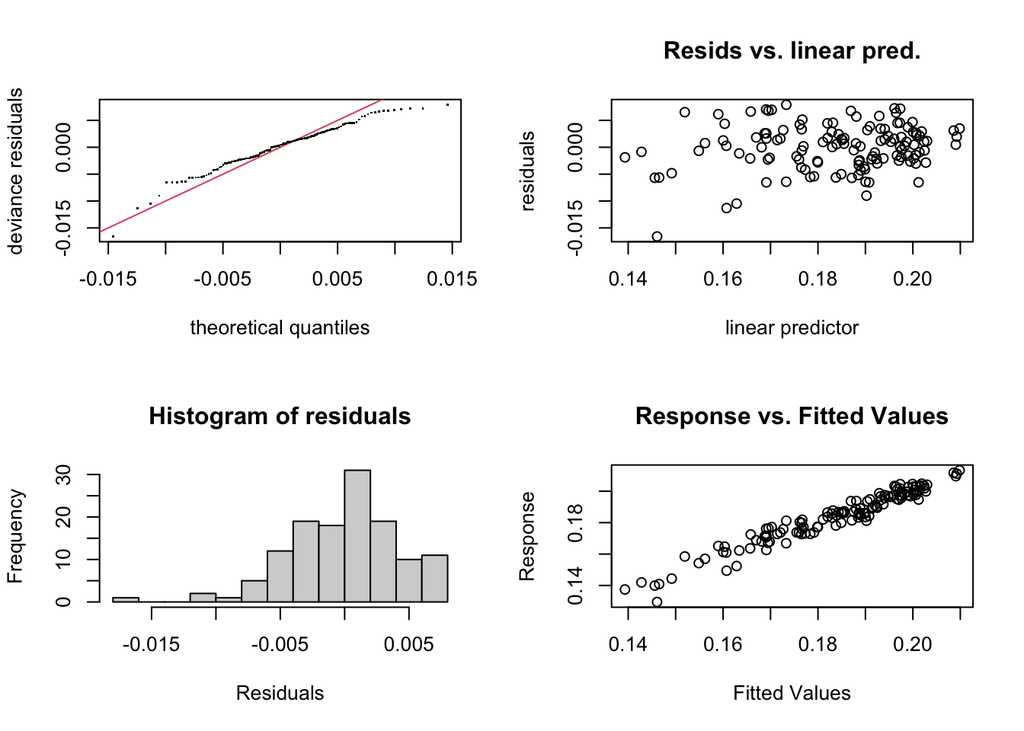

```
##
## Method: REML   Optimizer: outer newton
## full convergence after 11 iterations.
## Gradient range [-7.455947e-05,0.0002680352]
## (score -423.4821 & scale 3.003914e-05).
## Hessian positive definite, eigenvalue range [7.456885e-05,71.19211].
## Model rank =  125 / 125
##
## Basis dimension (k) checking results. Low p-value (k-index<1) may
## indicate that k is too low, especially if edf is close to k'.
##
##                    k'   edf k-index p-value
## ti(Corr_age)     8.00  3.83    1.15    0.96
## ti(GA)           4.00  1.00    1.11    0.90
## ti(Corr_age,GA) 32.00  1.26    1.08    0.85
## s(Unique_ID)    79.00 45.78      NA      NA
```

```r
model0.corr.fa = gam(WB_fa.combat~ti(Corr_age,k=9)+ti(GA,k=5)+ti(Corr_age,GA,k=c(9,5))+Sex+s(Unique_ID,bs='re'),method='REML',data=dat_harmonized)
gam.check(model0.corr.fa)
```

```r
summary(model0.corr.fa)
```

```
##
## Family: gaussian
## Link function: identity
##
## Formula:
## WB_fa.combat ~ ti(Corr_age, k = 9) + ti(GA, k = 5) + ti(Corr_age,
##     GA, k = c(9, 5)) + Sex + s(Unique_ID, bs = "re")
##
## Parametric coefficients:
##               Estimate Std. Error t value Pr(>|t|)
## (Intercept)  0.1839596  0.0013361 137.679   <2e-16 ***
## SexM        -0.0006089  0.0017104  -0.356    0.723
## ---
## Signif. codes:  0 '***' 0.001 '**' 0.01 '*' 0.05 '.' 0.1 ' ' 1
##
## Approximate significance of smooth terms:
##                    edf Ref.df       F p-value
## ti(Corr_age)     3.826  4.494 130.367  <2e-16 ***
## ti(GA)           1.000  1.001   0.158   0.692
## ti(Corr_age,GA)  1.258  1.403   0.323   0.776
## s(Unique_ID)    45.781 76.000   1.692   6e-06 ***
## ---
## Signif. codes:  0 '***' 0.001 '**' 0.01 '*' 0.05 '.' 0.1 ' ' 1
##
## R-sq.(adj) =  0.897   Deviance explained = 93.9%
## -REML = -423.48  Scale est. = 3.0039e-05  n = 129
```

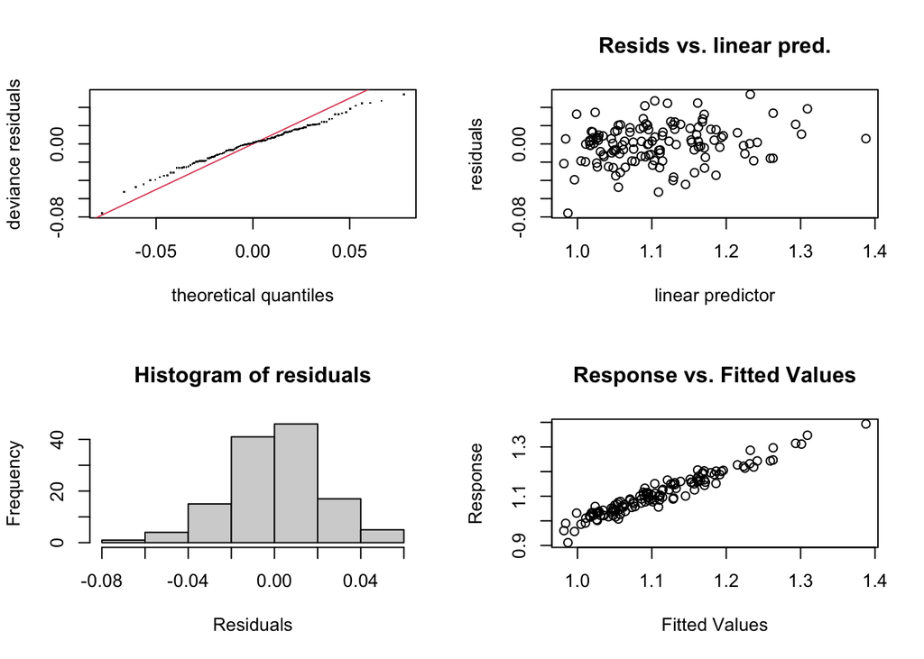

```
##
## Method: REML   Optimizer: outer newton
## full convergence after 10 iterations.
## Gradient range [-3.303084e-05,3.152813e-05]
## (score -207.8915 & scale 0.0008583038).
## Hessian positive definite, eigenvalue range [2.632327e-05,72.46235].
## Model rank =  125 / 125
##
## Basis dimension (k) checking results. Low p-value (k-index<1) may
## indicate that k is too low, especially if edf is close to k'.
##
##                    k'   edf k-index p-value
## ti(Corr_age)     8.00  4.11    0.94    0.18
## ti(GA)           4.00  1.00    1.22    0.97
## ti(Corr_age,GA) 32.00  2.85    0.99    0.42
## s(Unique_ID)    79.00 49.04      NA      NA
```

```r
model0.corr.md = gam(WB_md.combat~ti(Corr_age,k=9)+ti(GA,k=5)+ti(Corr_age,GA,k=c(9,5))+Sex+s(Unique_ID,bs='re'),method='REML',data=dat_harmonized)
gam.check(model0.corr.md)
```

```r
summary(model0.corr.md)
```

```
##
## Family: gaussian
## Link function: identity
##
## Formula:
## WB_md.combat ~ ti(Corr_age, k = 9) + ti(GA, k = 5) + ti(Corr_age,
##     GA, k = c(9, 5)) + Sex + s(Unique_ID, bs = "re")
##
## Parametric coefficients:
##             Estimate Std. Error t value Pr(>|t|)
## (Intercept) 1.096121   0.007682 142.679   <2e-16 ***
## SexM        0.020266   0.009865   2.054   0.0437 *
## ---
## Signif. codes:  0 '***' 0.001 '**' 0.01 '*' 0.05 '.' 0.1 ' ' 1
##
## Approximate significance of smooth terms:
##                    edf Ref.df      F  p-value
## ti(Corr_age)     4.111  4.790 86.837  < 2e-16 ***
## ti(GA)           1.000  1.000  0.424    0.517
## ti(Corr_age,GA)  2.851  3.245  2.130    0.121
## s(Unique_ID)    49.039 76.000  1.904 3.87e-06 ***
## ---
## Signif. codes:  0 '***' 0.001 '**' 0.01 '*' 0.05 '.' 0.1 ' ' 1
##
## R-sq.(adj) =  0.881   Deviance explained = 93.5%
## -REML = -207.89  Scale est. = 0.0008583  n = 129
```

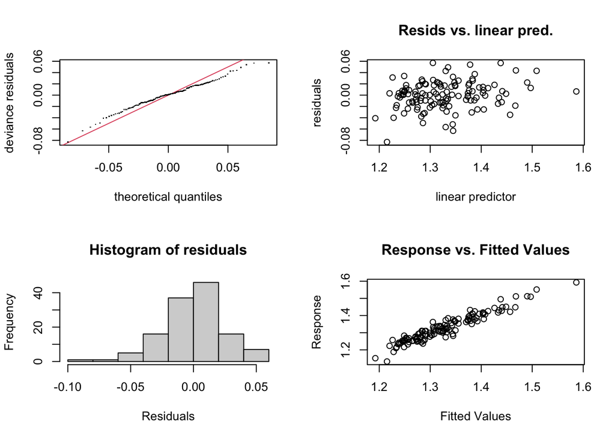

```
##
## Method: REML   Optimizer: outer newton
## full convergence after 10 iterations.
## Gradient range [-4.42978e-05,3.372907e-05]
## (score -205.1352 & scale 0.001002184).
## Hessian positive definite, eigenvalue range [3.833345e-05,70.6743].
## Model rank =  125 / 125
##
## Basis dimension (k) checking results. Low p-value (k-index<1) may
## indicate that k is too low, especially if edf is close to k'.
##
##                    k'   edf k-index p-value
## ti(Corr_age)     8.00  3.63    0.93    0.23
## ti(GA)           4.00  1.00    1.23    0.99
## ti(Corr_age,GA) 32.00  2.78    0.98    0.28
## s(Unique_ID)    79.00 45.06      NA      NA
```

```r
model0.corr.ad = gam(WB_ad.combat~ti(Corr_age,k=9)+ti(GA,k=5)+ti(Corr_age,GA,k=c(9,5))+Sex+s(Unique_ID,bs='re'),method='REML',data=dat_harmonized)
gam.check(model0.corr.ad)
```

```r
summary(model0.corr.ad)
```

```
##
## Family: gaussian
## Link function: identity
##
## Formula:
## WB_ad.combat ~ ti(Corr_age, k = 9) + ti(GA, k = 5) + ti(Corr_age,
##     GA, k = c(9, 5)) + Sex + s(Unique_ID, bs = "re")
##
## Parametric coefficients:
##             Estimate Std. Error t value Pr(>|t|)
## (Intercept) 1.314655   0.007670 171.396   <2e-16 ***
## SexM        0.022749   0.009838   2.312   0.0235 *
## ---
## Signif. codes:  0 '***' 0.001 '**' 0.01 '*' 0.05 '.' 0.1 ' ' 1
##
## Approximate significance of smooth terms:
##                    edf Ref.df      F  p-value
## ti(Corr_age)     3.632  4.282 72.399  < 2e-16 ***
## ti(GA)           1.000  1.000  0.335    0.564
## ti(Corr_age,GA)  2.776  3.176  1.973    0.138
## s(Unique_ID)    45.057 76.000  1.475 5.07e-05 ***
## ---
## Signif. codes:  0 '***' 0.001 '**' 0.01 '*' 0.05 '.' 0.1 ' ' 1
##
## R-sq.(adj) =  0.843   Deviance explained = 90.9%
## -REML = -205.14  Scale est. = 0.0010022  n = 129
```

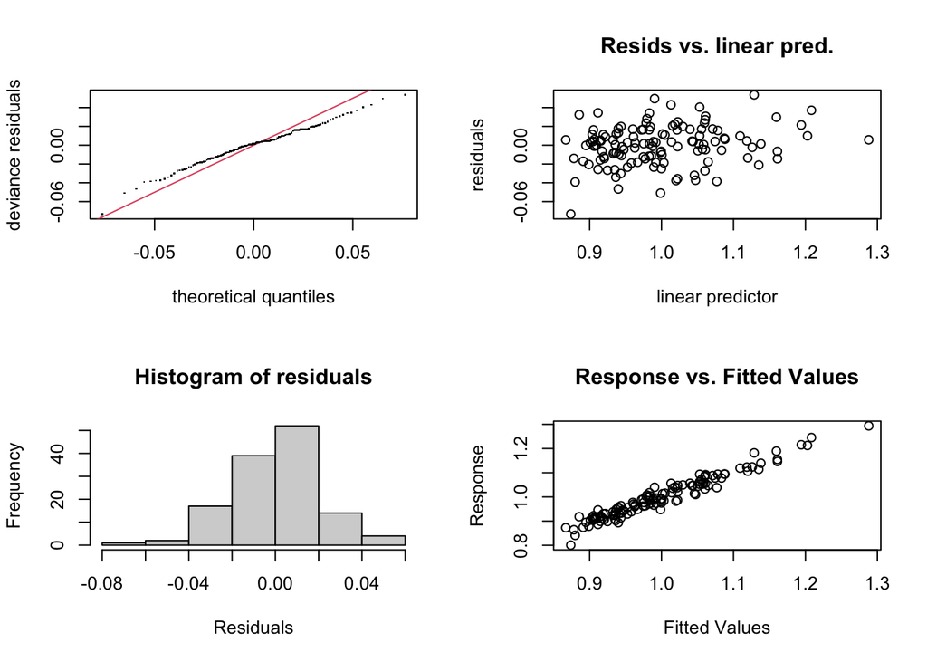

```
##
## Method: REML   Optimizer: outer newton
## full convergence after 10 iterations.
## Gradient range [-6.738718e-05,8.858795e-05]
## (score -207.9424 & scale 0.0008238407).
## Hessian positive definite, eigenvalue range [3.81971e-05,73.12745].
## Model rank =  125 / 125
##
## Basis dimension (k) checking results. Low p-value (k-index<1) may
## indicate that k is too low, especially if edf is close to k'.
##
##                    k'   edf k-index p-value
## ti(Corr_age)     8.00  4.26    0.94    0.25
## ti(GA)           4.00  1.00    1.22    0.99
## ti(Corr_age,GA) 32.00  2.86    1.00    0.51
## s(Unique_ID)    79.00 50.39      NA      NA
```

```r
model0.corr.rd = gam(WB_rd.combat~ti(Corr_age,k=9)+ti(GA,k=5)+ti(Corr_age,GA,k=c(9,5))+Sex+s(Unique_ID,bs='re'),method='REML',data=dat_harmonized)
gam.check(model0.corr.rd)
```